# Лабораторная работа №5

Операционные системы

Верниковская Е. А., НПИбд-01-23

Российский университет дружбы народов, Москва, Россия

14 марта 2024

# Вводная часть

## Цель работы

Настроить рабочую среду и получить навыки работы с менеджером паролей pass и с chezmoi.

## Задание

1. Установить gopass и настроить всё, что надо.
2. Настроить интерфейс с браузером.
3. Установить chezmoi.
4. Использовать chezmoi на нескольких машинах.

# Выполнение лабораторной работы

## Менеджер паролей pass

РАБОТА С МЕНЕДЖЕРОМ ПАРОЛЕЙ PASS

## Установка

Устанавливаем pass введя *sudo dnf install pass pass-otp* (рис. 1)

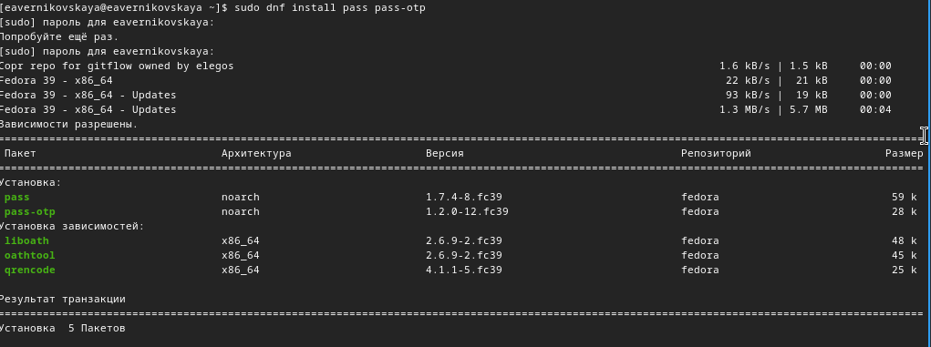

Установка pass

## Установка

Устанавливаем gopass введя *sudo dnf install gopass* (рис. 2)

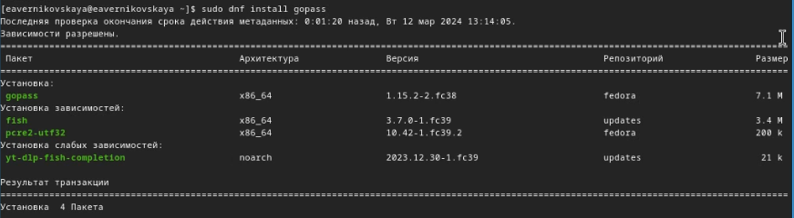

Установка gopass

## Настройка

Просмотрим список ключей, введя *gpg –list-secret-keys* (рис. 3)

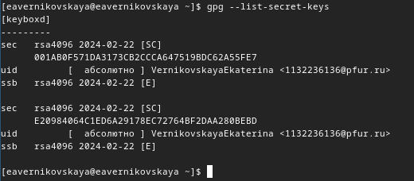

Список ключей

## Настройка

Далее инициализируем хранилище командой *pass init* . Я ввела email (рис. 4)

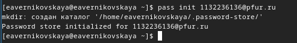

Инициализация хранилища

## Настройка

После создаём структуру git с помощью *pass git init* (рис. 5)

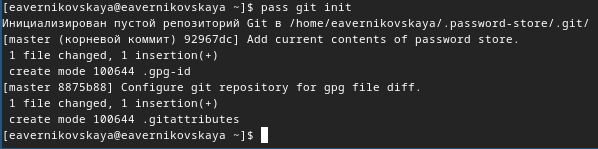

Создание структуры git

## Настройка

Далее создаём репозиторий с именем pass (рис. 6)

[figure not shown]

Создание репозитория

## Настройка

Потом выполняем синхронизацию с помощью двух команд *pass git push* и *pass git pull* (рис. 8)

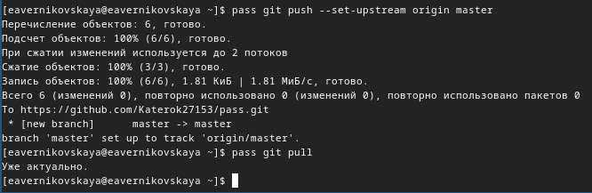

Синхронизация

## Настройка

Далее вручную коммитим и выкладываем изменения (рис. 9)

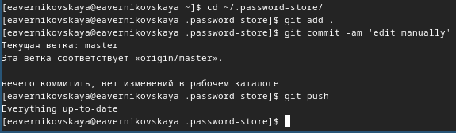

Выкладываем изменения

## Настройка

Проверяем статус синхронизации командой *pass git status* (рис. 10)

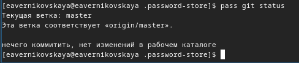

Проверка статуса синхронизации

## Настройка интерфейса с браузером

Переходим на сайт с плагином для Firefox и добавляем этот плагин (рис. 11)

[figure not shown]

Сайт с плагтином для Firefox

## Настройка интерфейса с браузером

Далее подключаем репозиторий и скачиваем browserpass, с помощью двух команд: *dnf copr enable maximbaz/browserpass* и *dnf install browserpass* (рис. 12), (рис. 13)

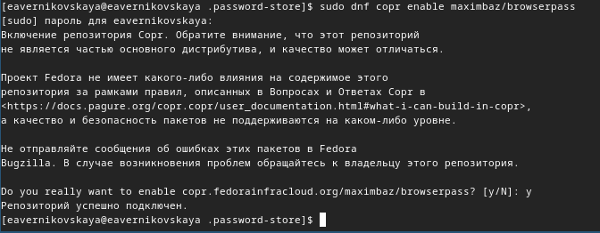

Подключение репозитория

## Настройка интерфейса с браузером

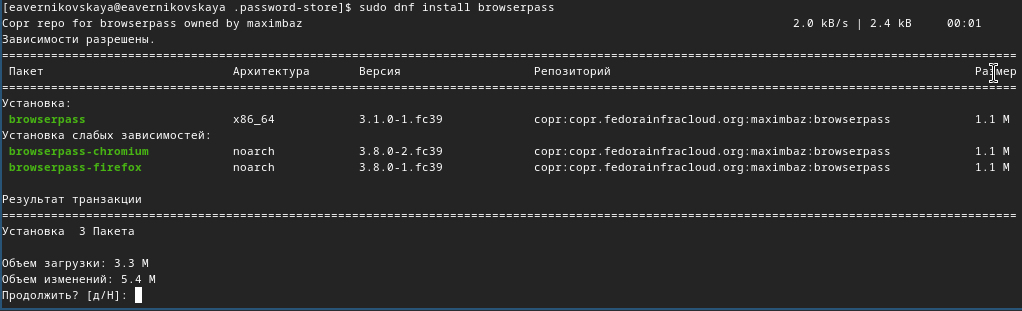

Установка browserpass

## Сохранение пароля

Создаём новый файл с помощью *touch* и добавляем пароль с помощью команды *pass insert [FILENAME]* (рис. 14)

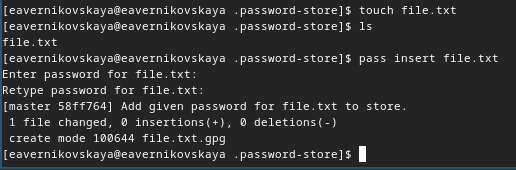

Добавление пароля

## Сохранение пароля

Отображаем пароль для указанного файла командой *pass [FILENAME]* (рис. 15)

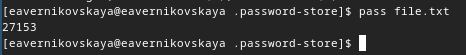

Отображение пароля

## Сохранение пароля

Далее можно заменить существующий пароль командой *pass generate –in-place FILENAME*. Сгенерируется новый рандомный пароль (рис. 16)

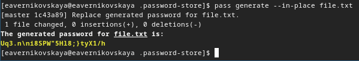

Генерируем новый пароль

## Управление файлами конфигурации

РАБОТА С CHEZMOI

## Дополнительное программное обеспечение

Устанавливаем дополнительтное программное обеспечение с помощью *sudo dnf -y install* (рис. 17), (рис. 18), (рис.19), (рис. 20), (рис. 21), (рис. 22), (рис. 23), (рис. 24), (рис. 25), (рис. 26]), (рис. 27), (рис. 28)

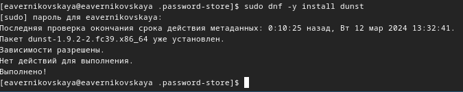

Установка dunst

## Дополнительное программное обеспечение

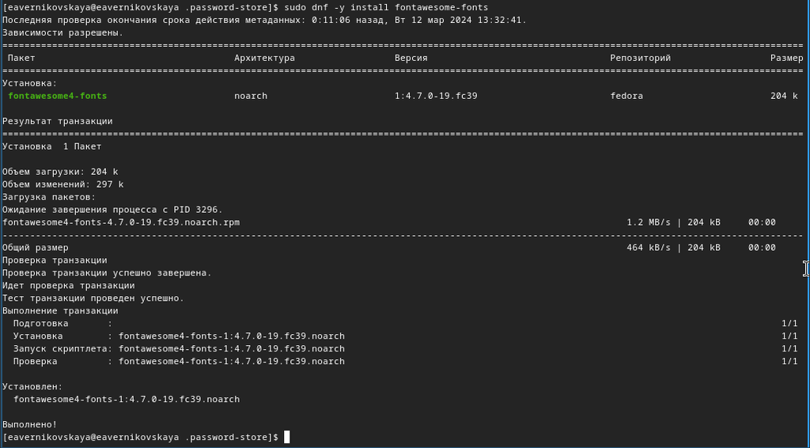

Установка fontawesome-fonts

## Дополнительное программное обеспечение

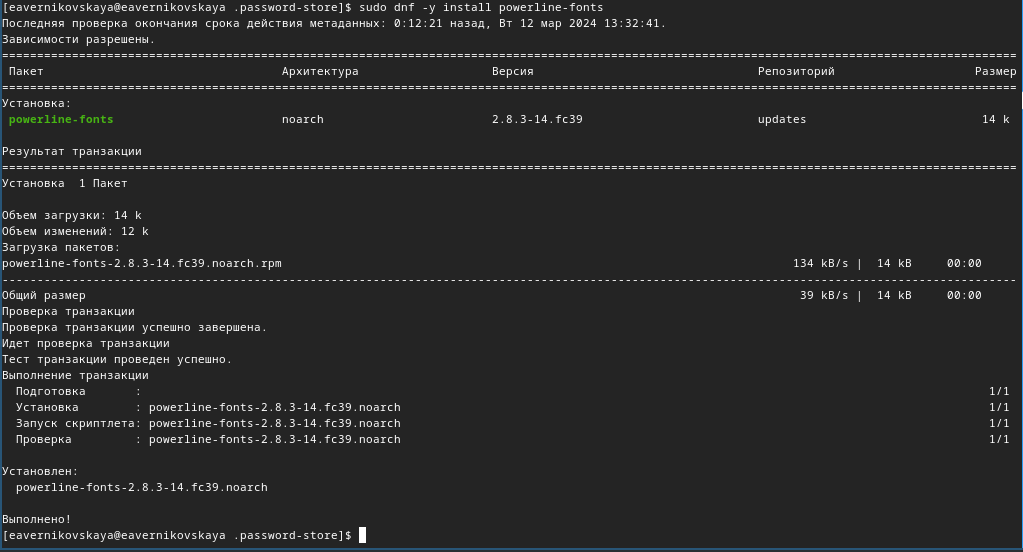

Установка powerline-fonts

## Дополнительное программное обеспечение

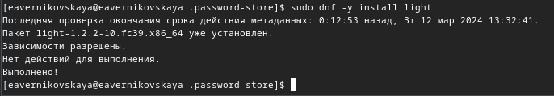

Установка light

## Дополнительное программное обеспечение

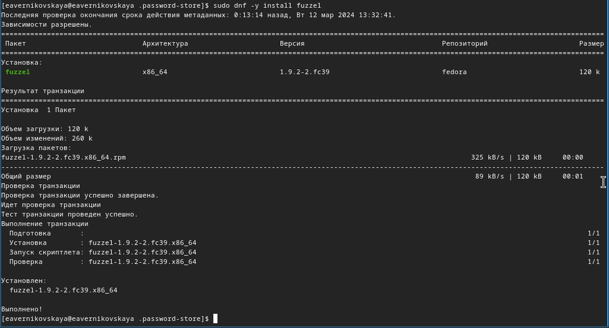

Установка fuzzel

## Дополнительное программное обеспечение

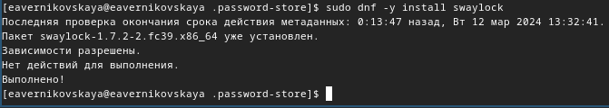

Установка swaylock

## Дополнительное программное обеспечение

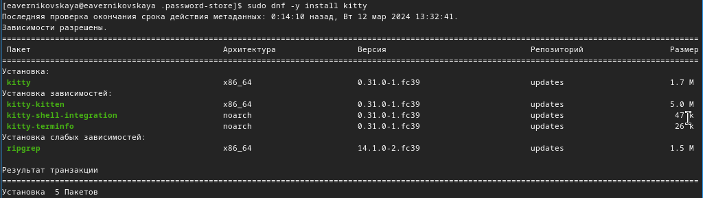

Установка kitty

## Дополнительное программное обеспечение

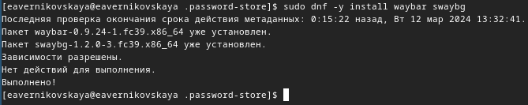

Установка waybar swaybg

## Дополнительное программное обеспечение

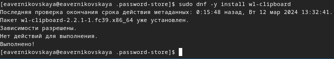

Установка wl-clipboard

## Дополнительное программное обеспечение

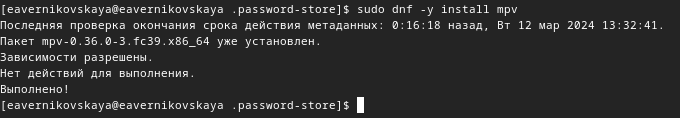

Установка mpv

## Дополнительное программное обеспечение

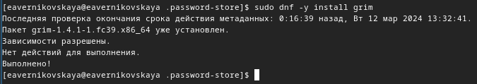

Установка grim

## Дополнительное программное обеспечение

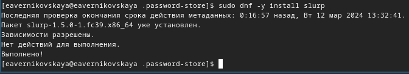

Установка slurp

## Дополнительное программное обеспечение

Далее устанавливаем шрифты. Сначала подключаем репозиторий, потом ищем нужное название и устанавливаем нужные шрифты (рис. 29), (рис. 30), (рис. 31)

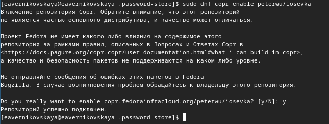

Подключение репозитория

## Дополнительное программное обеспечение

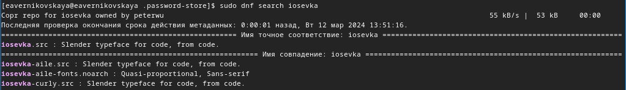

Поиск iosevka

## Дополнительное программное обеспечение

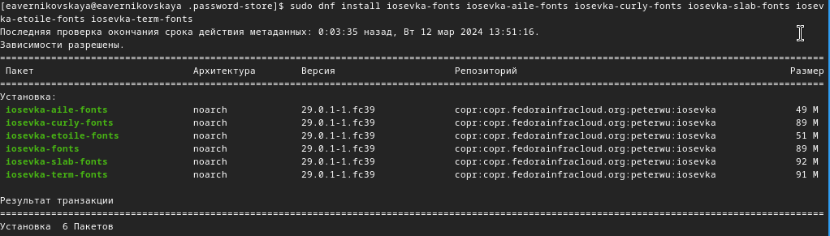

Установка шрифтов

## Установка

Устанавливаем chezmoi с помощью команды *sh -c “$(wget -qO- chezmoi.io/get)”* (рис. 32)

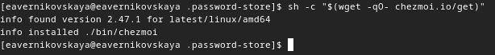

Установка chezmoi

## Создание собственного репозитория с помощью утилит

Создаём свой репозиторий для конфигурационных файлов на основе шаблона, с помощью *gh repo create* (рис. 33)

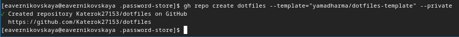

Создание репозитория на основе шаблона

## Подключение репозитория к своей системе

Инициализируем chezmoi с нашим репозиторием dotfiles (рис. 34)

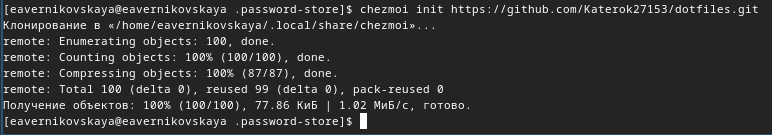

Инициализация chezmoi с dotfiles (1)

## Использование chezmoi на нескольких машинах

В качестве второй виртуальной машины я выбрала kali. Сначала устанавливаем на kali chezmoi (рис. 37)

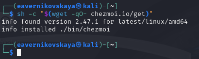

Установка chezmoi на kali

## Использование chezmoi на нескольких машинах

На второй машине инициализируем chezmoi с нашим репозиторием dotfiles (рис. 38)

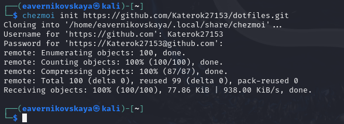

Инициализация chezmoi с dotfiles (2)

## Использование chezmoi на нескольких машинах

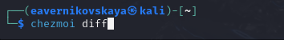

## Использование chezmoi на нескольких машинах

Выполняем команду *chezmoi update -v* - получаем и применяем последние изменения из нашего репозитория (рис. 41)

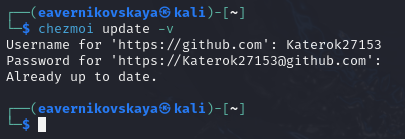

Ввод команды chezmoi update -v

## Настройка новой машины с помощью одной команды

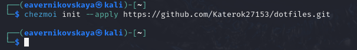

Настройка с помощью одной команды

## Ежедневные операции c chezmoi

Извлекаем изменения из репозитория и применяем их одной командой *chezmoi update* (рис. 43)

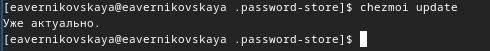

Ввод команды chezmoi update

## Ежедневные операции c chezmoi

Далее выполняем *chezmoi git pull – –autostash –rebase && chezmoi diff* (рис. 44])

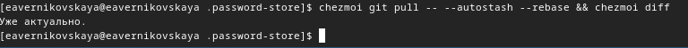

Извлечение последних изменений

## Ежедневные операции c chezmoi

Так как мы довольны изменениями то применяем их введя команду *chezmoi apply* (рис. 45)

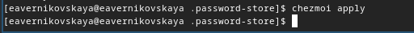

Применение изменений

## Ежедневные операции c chezmoi

Включем функцию автоматического фиксирования и отправки изменений в репозиторий добавив в файл конфигурации ~/.config/chezmoi/chezmoi.toml следующее: - [git] autoCommit = true autoPush = true (рис. 46)

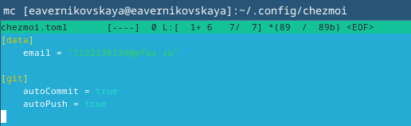

Редоктирование файла

# Подведение итогов

## Выводы

В ходе выполнения лабораторной рбаоты мы настроили рабочую среду и получили навыки работы с менеджером паролей pass и с chezmoi.

## Список литературы

1. Лаборатораня работа №5 [Электронный ресурс] URL: https://esystem.rudn.ru/mod/page/view.php?id=1098939#org2695679
2. Плагин для Firefox[Электронный ресурс] URL: https://addons.mozilla.org/en-US/firefox/addon/browserpass-ce/.